# Part II - Prosper Loan Data Exploration

## by Ayame God'swill Claude

## Investigation Overview

In this project, I meant to investigate and provide findings for the following insights:

> INSIGHT #1: Which features affect the borrower’s APR or interest rate variable? Put differently, which variables (predictors) have a bearing on the values of the BorrowerAPR (target) variable?

> INSIGHT #2: What factors affect a loan’s outcome status? In other words, which of the following variables are predictors of the LoanStatus variable?

## Dataset Overview

> This project is concerned with the exploration and visualization of the loan data from Prosper (a registered, legitimate lending company in the United States). The dataset contains 113,937 loans with 81 variables on each loan, including loan amount, borrower rate (or interest rate), current loan status, borrower income and many others. However, this project does not attempt to explore all of the variables in the dataset; we will focus our exploration on about 10-15 of them.

## (Visualization 1)

> What affects the borrower’s APR or interest rate? Put differently, which variables (predictors) have a bearing on the values of the BorrowerAPR (target) variable?

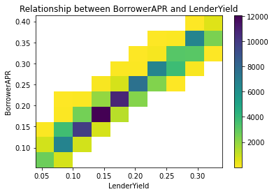

The visualization above shows that there is a strong direct (positive) relationship/correlation between BorrowerAPR and LenderYield. So, the wanted yield of the borrower (Prosper company) for a particular loan determines the APR fixed on it

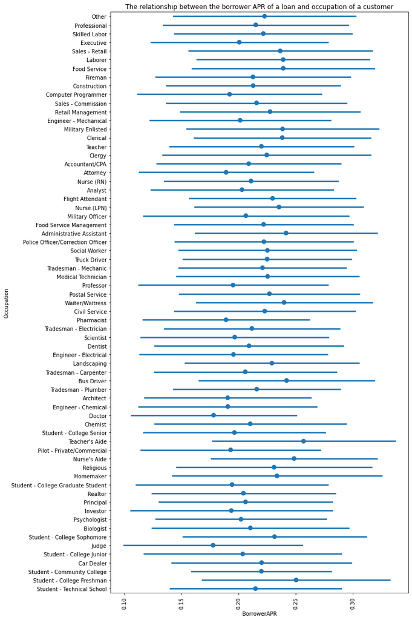

It's quite obvious that Occupation is a good determining factor of the BorrowerAPR, with Teacher's Aide having the highest APR. This goes without saying that Teacher's Aide occupation loan takers would receive the lowest loan original amount, since there it has an inverse relationship with BorrowerAPR

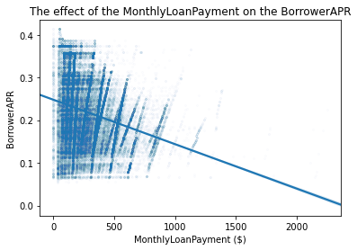

MonthlyLoanPayment has a weak negative correlation with the BorrowerAPR on a loan, which implies it has an inverse relationship with BorrowerAPR.

## (Visualization 2)

> What factors affect a loan’s outcome status? In other words, which variables are predictors of the LoanStatus variable?

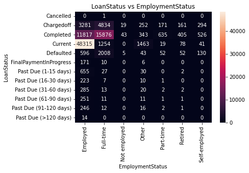

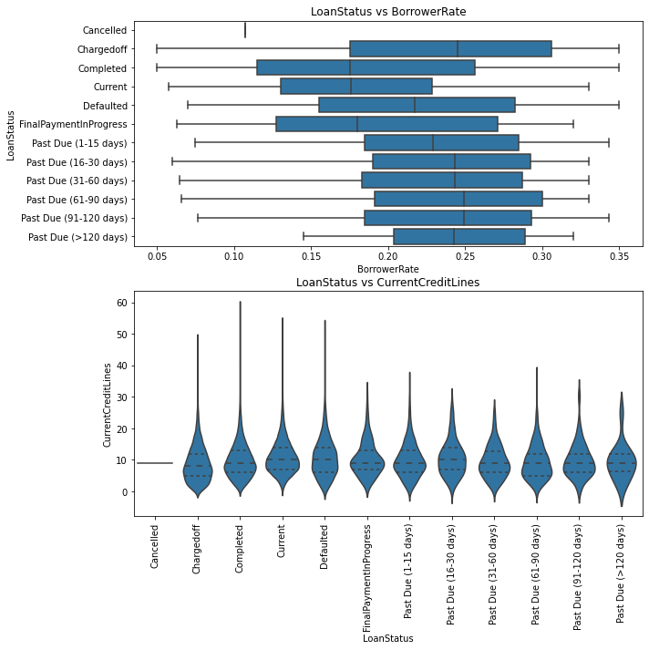

The visualizations above reveal that only BorrowerRate has a bearing on a loan's outcome status, while CurrentCreditLines does not appreciably affect it.

More so, it can be seen that loans with higher borrower rates end up being defaulted, paid late or chargedoff, while those with lower borrower rates are either completely paid back or in the process of being paid.

## (Visualization 3)

If a customer is both employed and is a homeowner, does this affect the amount of loan he can be given by Prosper? Would Prosper company consider him more eligible to pay back the loan completely?

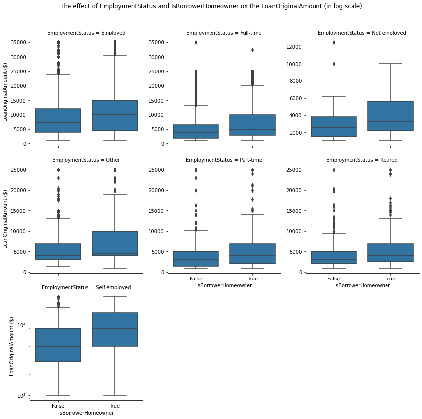

As seen above, in all cases if a borrower is a homeowner the loan original amount obtainable is higher, whether the borrower is employed or not, although in cases where employed the amount obtainable is higher than when not employed. This may be due to the fact that the property could be used as collateral by the borrower, making them appear less of a risk to transact with by Prosper company